# TRATAMIENTO DE DATOS CON R

Joaquín Planelles Romero e Isabel Padilla Sánchez

octubre de 2021

# **Combinar tablas**

Llegados a este punto, hemos explicado prácticamente todas las funcionalidades de la librería dplyr. Lo podéis comprobar repasando la chuleta. Estamos pues, a punto de terminar a falta de ver cómo combinar las tablas. La librería dplyr nos permite combinar tablas de dos formas distintas ¿se os ocurre cómo pueden ser? Efectivamente, se pueden combinar tanto por filas como por columnas. De este modo, como venimos haciendo vamos a distinguir qué comandos se utilizan para combinar variables y cuáles usamos para combinar filas.  
Para verlo, debemos distinguir dos conceptos: (1) anexar filas o columnas a nuestra tabla y (2) cruzar tablas a partir de identificadores comunes.

### 1. Sin identificador

En muchas ocasiones nos interesa combinar tablas que no tienen un identificador común. Podemos unir filas o columnas. Por un lado, para unir filas los data.frame tienen que tener el mismo número de variables y además éstas tienen que tener el mismo nombre para que no falle el comando. Por otro, para pegar columnas de un data.frame a otro, estos deben tener el mismo número de filas tal y como se muestra en la imagen de la chuleta

COLUMNAS

FILAS

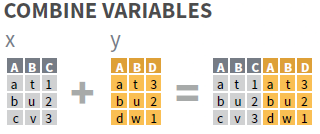

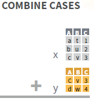

### 2. Con identificadores comunes:

Cuando añadimos a un data.frame información procedente de otro mediante uno o más identificadores comunes, se añaden columnas y filas de forma simultánea. Esto se hace mediante los join que son utilizados en la mayoría de los lenguajes de programación. En el lenguaje de programación R y más concretamente la librería dplyr, dispone de sus propios comandos para cruzar tablas.

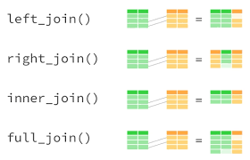

# 1 - Unir columnas

Tenemos dos formas de unir columnas:

### 1. Sin identificador

Si tenemos dos o más vectores con el **mismo número de filas**, existe la posibilidad de unirlos en una única tabla mediante la función `bind_cols()`. Para utilizar este comando debemos tener la precaución de que los vectores se encuentran ordenados según nos interesa a nosotros ya que con esta función, se unen tal cual se encuentran.  
En el dibujo que hay en la chuleta se ve claro el funcionamiento del comando. En el paquete base de R hay una función, `cbind()`, con exactamente la misma funcionalidad. Una diferencia importante es que cbind puede crear diferentes tipos de objetos, mientras bind_cols siempre produce un data.frame.

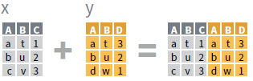

El código equivalente sería:

```r
Ejemplo <- datos %>% bind_cols(X,Y)
```

Supongamos que tenemos el gasto (en millones de euros) de los hogares andaluces desde 2016 extraído de la EPF y los hogares y personas que nos ofrece esta encuesta desde 2015. Queremos calcular el *gasto medio por hogar* y *gasto medio por persona* para la serie en euros. Podéis cargar los datos vosotros mismos mediante las siguientes líneas:

```r
Gasto    <- data.frame(Anual = c(2016, 2017, 2018, 2019, 2020),
                       Gasto = c(81694.9, 87273.8, 89698.4, 87728.1, 77813.4))

Hog_pers <- data.frame(Anual    = c(2015, 2016, 2017, 2018, 2019, 2020),
                       Hogares  = c(3185644, 3200824, 3209119, 3219776, 3230808, 3259782),
                       Personas = c(8343892, 8345293, 8347526, 8352389, 8389632, 8426501))
```

Para ello filtramos aquellos registros que no sean 2015 y seleccionamos solo las dos columnas a pegar, que como están en orden, se pueden unir correctamente con **bind_cols** como vemos. Una vez tenemos todos los datos en un mismo tibble, podemos crear las nuevas columnas con los cálculos que se pedían.

```r
Hog_pers1 <- Hog_pers %>% filter(Anual!= 2015) %>% select(Hogares,Personas)

datos     <- bind_cols(Gasto,Hog_pers1) %>% mutate(gmh = Gasto /Hogares*1000000,
                                                   gmp = Gasto /Personas*1000000)
```

### 2. Con identificador

Son las llamadas ‘mutating join’ que agregan nuevas variables a un data.frame a partir de las observaciones coincidentes en otra tabla. Las funciones join son las más utilizadas en el cruce de tablas.

Función

Ejemplo

Uso

left_join(x,y,by=‘key’)

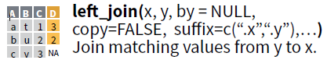

mantiene todas las observaciones en x

right_join(x,y,by=‘key’)

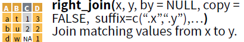

mantiene todas las observaciones en y

inner_join(x,y,by=‘key’)

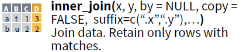

une pares de observaciones siempre que sus claves sean iguales

full_join(x,y,by=‘key’)

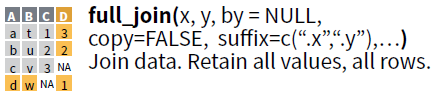

mantiene todas las observaciones en x e y

semi_join(x,y,by=‘key’)

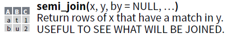

mantiene todas las observaciones en x con coincidencias en y

anti_join(x,y,by=‘key’)

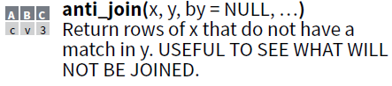

descarta todas las observaciones en x con coincidencias en y

Hasta ahora, los pares de tablas siempre se une de acuerdo a una o más variables que tienen en común. Estas variables no tienen por qué tener el mismo nombre. Esta restricción se expresa de la forma by = “key”. De forma general, se pueden presentar 3 situaciones:

- Cuando no aparece el argumento **by** la unión se hace por la columnas coincidentes entre ambas tablas. Es lo que se conoce como **unión natural**.
- by= ‘COLUMNA’ La unión se hace por la columnas que nosotros indicamos y que están en ambas tablas. En el caso de que sean varias by=c(‘COLUMNA1’,‘COLUMNA2’)
- by = c(“a” = “b”) Se hace la unión por columnas que tienen diferentes nombres en ambas tablas.

```r
df <- inner_join(Gasto,Hog_pers,by='Anual') %>% mutate(gmh=`Gasto total`/Hogares*1000,
                                                       gmp=`Gasto total`/Personas*1000)
```

Si queremos que nos aparezcan todos los datos, es decir, teniendo en cuenta los hogares y personas de 2015 aunque no podamos calcular el indicador tendremos que usar un right_join (si ponemos el data.frame Hog_pers a la derecha).

```r
df <- right_join(Gasto,Hog_pers,by='Anual') %>% mutate(gmh=`Gasto total`/Hogares*1000,
                                                       gmp=`Gasto total`/Personas*1000)
```

NOTA: el resultado de utilizar la función `right_join()` en este caso, sería el mismo que el obtenido con `full_join()` ya que con right_join incluimos todos los registros del fichero Hog_pers y los que coincidan del fichero Gasto (que en este caso son todas las filas). Con full_join, incluimos todas las filas de ambos data.frame.

```r
df <- left_join(Hog_pers,Gasto,by='Anual') %>% mutate(gmh=`Gasto total`/Hogares*1000,
                                                      gmp=`Gasto total`/Personas*1000)
```

Vemos que dependiendo del orden en que coloquemos los data.frame dentro del comando join tendremos que usar left_join o right_join para obtener el resultado esperado.

# 2 - Operadores de filas

A diferencia de las funciones join, las funciones binding (o de pegado) no intentan coincidir con una variable, sino que simplemente combinan sets de datos. Si los sets de datos no coinciden con las dimensiones apropiadas, se obtiene un error.

### 1. Pegado de filas

Al igual que podemos unir columnas, también podemos podemos hacerlo con las filas de dos o más tablas. Un requisito fundamental es que los data.frame tienen que tener el **mismo número de columnas**. Para ello utilizamos el comando de dplyr `bind_rows()`.  
En el paquete base de R hay una función, `rbind()`, con exactamente la misma funcionalidad. Una diferencia importante es que rbind puede crear diferentes tipos de objetos, mientras bind_rows siempre produce un data.frame.

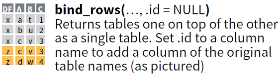

Supongamos que los dos ficheros anteriores los queremos con otra estructura. Queremos pegar las filas del gasto, de los hogares y de los datos que corresponden a personas indicando en cada una de ellas la característica de la información que contiene. Para poder hacer esta práctica hay que tener en cuenta dos cosas:

- El nombre de las columnas que pegamos tienen que tener el mismo nombre y ser del mimo tipo de dato.
- Para distinguir qué dato estamos pegando, añadimos una nueva columna ‘Categoría’ qué nos dice si el dato pertenece a hogares, gasto o personas.

```r
Personas <- Hog_pers %>% select(Anual,datos=Personas)      %>% mutate(Categoría='Personas')
hogares  <- Hog_pers %>% select(Anual,datos=Hogares)       %>% mutate(Categoría='Hogares')
Gasto    <- Gasto    %>% select(Anual,datos=`Gasto total`) %>% mutate(Categoría='Gasto')

EPF<-bind_rows(Personas,hogares,Gasto)
head(EPF)
```

```
## # A tibble: 6 x 3
##   Anual    datos Categoría
##   <dbl>    <dbl> <chr>
## 1  2015 8343892. Personas
## 2  2016 8345293. Personas
## 3  2017 8347526. Personas
## 4  2018 8352389. Personas
## 5  2019 8389632. Personas
## 6  2020 8426501. Personas
```

### 2. Otros operadores (Bonus track)

Este apartado va de regalo con el curso, lo que queremos decir es que estos comandos los vamos a nombrar para que sepáis de su existencia y compilar unos ejemplos simples para ilustrar su funcionamiento. Son operadores que implican a dos tablas con las que se pueden hacer operaciones de conjunto. Todas estas operaciones funcionan con una fila completa, comparando los valores de cada variable. Esto espera que los input x e y tengan las mismas variables y trata las observaciones como conjuntos. Cuando se aplican a los vectores, estos se comportan como lo sugieren sus nombres. Ejemplos son intersect, union, setdiff y setequal. Sin embargo, si se carga el tidyverse, o más específicamente dplyr, estas funciones se pueden usar en data.frames.

Función

Uso

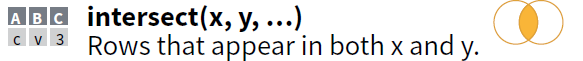

se puede aplicar a tablas con los mismos nombres de columna. Esta función devuelve las filas en común entre dos tablas

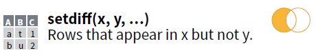

devuelve las observaciones en x pero no en y.

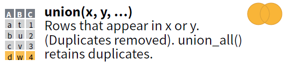

combina todas las filas de dos tablas con los mismos nombres de columna.

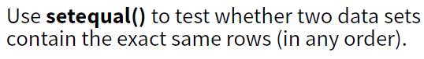

nos dice si dos data.frame son iguales, independientemente del orden

Supongamos que tenemos dos tibbles `A` y `B` con las variables Sexo, Edad y Frec (frecuencia absoluta de las personas que presentan la combinación de categorías de los atributos). En ambos hemos marcado con colores (rojo y azul) los valores de los registros que difieren.

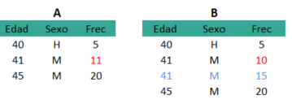

#### `intersec()`

Las dos filas comunes a ambas tablas son las que se muestra en el siguiente script. Son filas que tienen sus registros idénticos. Si alguno de los valores de las variables varía, ya no se considera que el registro es igual aunque los demás valores de las variables coincidan como es el caso de los datos marcados en rojo y claramente el registro marcado en azul tampoco.

```r
C <- intersect(A,B)
C
```

```
##   Edad Sexo Frec
## 1   40    H    5
## 2   45    M   20
```

#### `setdiff()`

Con setdiff buscamos los registros del tibble A que no están en el B. Como podéis comprobar solo hay una fila con esta característica.

```r
C <- setdiff(A,B)
C
```

```
##   Edad Sexo Frec
## 1   41    M   11
```

#### `union()`

La unión de A y B incluye todos los registros de ambos data.frame. Los que son iguales los incluye solo una vez y en este caso, el segundo registro del A y el segundo del B los considera dos registros distintos.

```r
C <- union(A,B)
C
```

```
##   Edad Sexo Frec
## 1   40    H    5
## 2   41    M   11
## 3   45    M   20
## 4   41    M   10
## 5   41    M   15
```

#### `setequal()`

Por último, este comando nos indica si los dos data.frame que estamos comparando son iguales o no. Como vemos la sentencia devuelve `FALSE` por tanto no son iguales (obviamente).

```r
C <- setequal(A,B)
C
```

```
## [1] FALSE
```

# Preguntas de auto-evaluación

El objetivo de las siguientes preguntas es que podáis auto-evaluar si habéis adquirido los conocimientos. Encontraréis las respuestas en la pestaña de soluciones.

- **Pregunta 1**. ¿Qué función de dplyr puedes usar para pegar columnas de dos estructuras de datos?
  1. cbind
  2. bind_cols
  3. super_join
  4. bind_rows
- **Pregunta 2**. Con los dos ficheros siguientes realiza un anti_join con Personas1 y Personas2 en ese orden. ¿Qué persona resulta?

  ```r
  Personas1 <- data.frame(Nombre = c('María', 'Pablo'),
                          Edad   = c(35,34))
  Personas2 <- data.frame(Nombre = c('María', 'Sara'),
                          Edad   = c(35,40))
  P2 <- anti_join(Personas1,Personas2)
  ```

  1. Pablo
  2. María
  3. Sara
  4. No hay coincidencia
- **Pregunta 3**. ¿Y si en vez de un anti_join aplicamos un intersect?
  1. Pablo
  2. María
  3. Sara
  4. No hay coincidencia

  ```r
  P3 <- intersect(Personas1,Personas2)
  ```

- **Pregunta 4**. Utilizando las tablas A y B ¿Qué función de dplyr usarías para obtener los resultados de las tablas C1 a C6?

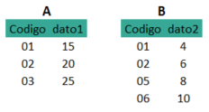

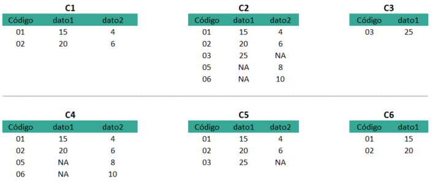

# Soluciones

A continuación se muestran, marcadas y en rojo, las soluciones a las preguntas de auto-evaluación

- **Pregunta 1**. ¿Qué función de dplyr puedes usar para pegar columnas de dos estructuras de datos?
  1. cbind
  2. **bind_cols**
  3. super_join
  4. bind_rows
- **Pregunta 2**. Con los dos ficheros siguientes realiza un anti_join con Personas1 y Personas2 en ese orden. ¿Qué persona resulta?
  1. **Pablo**
  2. María
  3. Sara
  4. No hay coincidencia

  **En concreto, hemos utilizado el siguiente código para obtener el resultado:**

  ```r
  Personas1 <- data.frame(Nombre = c('María', 'Pablo'),
                          Edad   = c(35,34))
  Personas2 <- data.frame(Nombre = c('María', 'Sara'),
                          Edad   = c(35,40))
  P2 <- anti_join(Personas1,Personas2)
  ```

- **Pregunta 3**. ¿Y si en vez de un anti_join aplicamos un intersect?
  1. Pablo
  2. **María**
  3. Sara
  4. No hay coincidencia

  **En concreto, hemos utilizado el siguiente código para obtener el resultado:**

  ```r
  P3 <- intersect(Personas1,Personas2)
  ```

- **Pregunta 4**. Utilizando las tablas A y B ¿Qué función de dplyr usarías para obtener los resultados de las tablas C1 a C6?

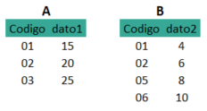

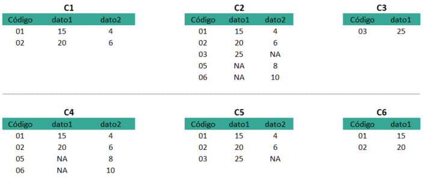

  **En concreto, hemos utilizado el siguiente código para obtener el resultado:**

  ```r
          A <- data.frame(Código = c('01','02','03'),
                          Dato1  = c(15,20,25))
          B <- data.frame(Código = c('01','02','05','06'),
                          Dato2  = c(4,6,8,10))
          #Para cada apartado, el data.frame C se obtiene de la siguiente forma:

          # (1) C1 <- inner_join(A,B,by='Código')
          # (2) C2 <- full_join(A,B,by='Código')
          # (3) C3 <- anti_join(A,B,by='Código')
          # (4) C4 <- right_join(A,B,by='Código')
          # (5) C5 <- left_join(A,B,by='Código')
          # (6) C6 <- semi_join(A,B,by='Código')
  ```